# Logistic Growth Part II

11/22/2021

## Continuous time logistic growth curves

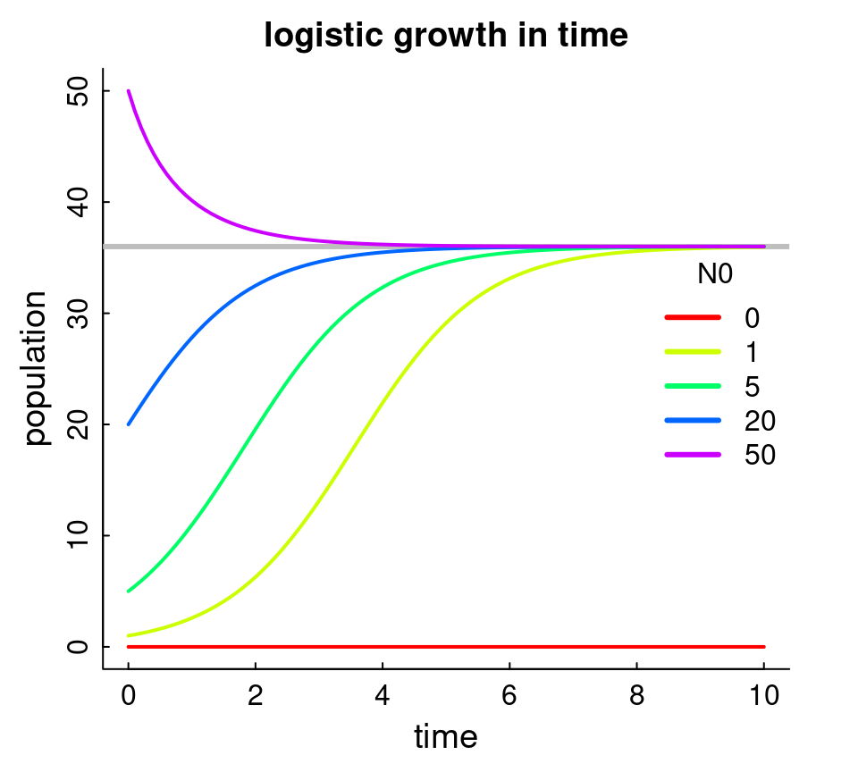

- Exponential growth at low \(N_0\), low values of time
- Typical “S” shape (**sigmoidal**) coming from below … Slows down at \(K\)
- Decays to \(K\) if \(N_0 > K\)

## Exponential vs. Logistic Growth in Three Graphs

### Exponential

differential equation: \({dN \over dt} = r N\)

solution: \(N(t) = N_0e^{rt}\)

### Logistic

differential equation: \({dN \over dt} = r_0 N\left(1-{N\over K}\right)\)

solution: \(N(t) = {K \over 1 + \left({K-N_0 \over N_0}\right)e^{-r_0 t}}\)

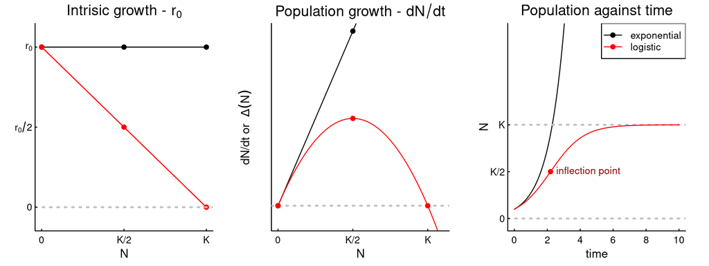

## Properties

Inflection point - where rate of growth is maximum - occurs at \(N(t^*) = K/2\)) \[t^* = {1\over r} \log\left({K- N_0 \over N_0}\right)\]

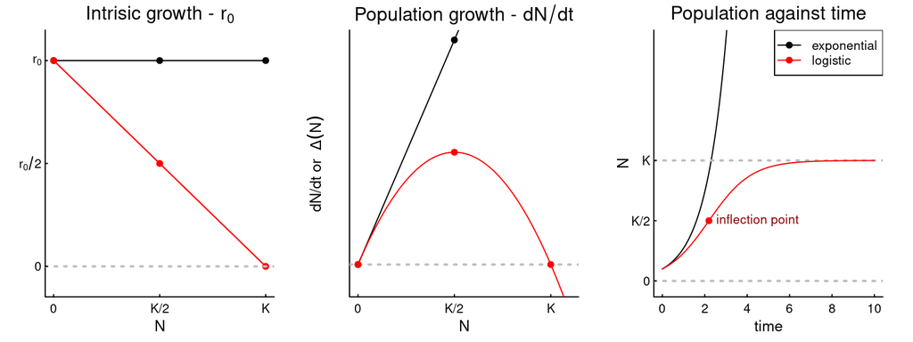

## Pierre François Verhulst

[figure not shown]

(1804-1849)

*Sur la loi d’accroissement de la population* - 1844

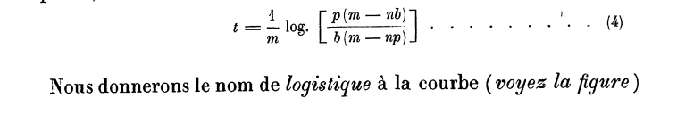

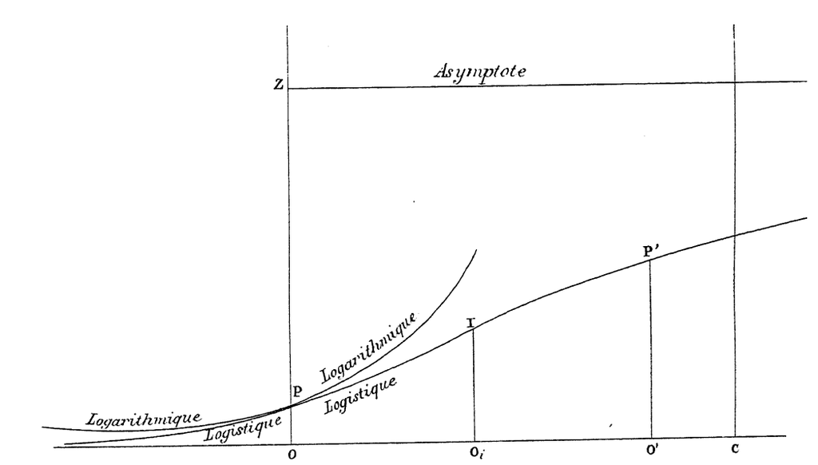

At the end of paper makes predictions - based purely on extrapolating from the inflection point:

*The extreme limit of the population of France is 40,000,000 souls, and of Belgium is 6,600,000 souls.*

## Different functional forms

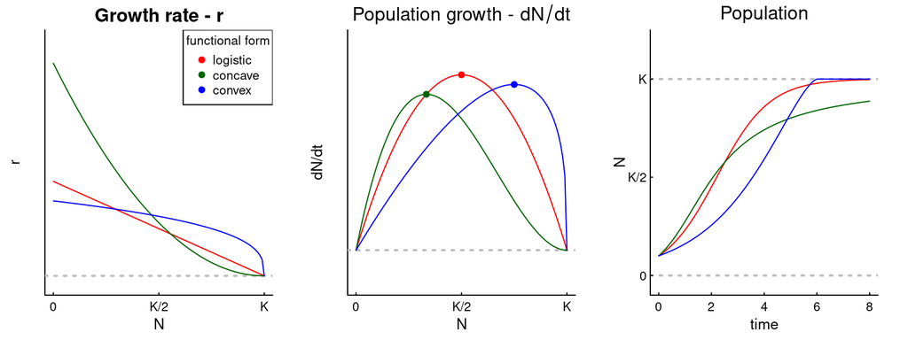

## Discrete logistic growth

Take discrete population growth equation:

\[N_{t+1} = \lambda N_t\]

break up into “stable” and “growth” components (\(\lambda = 1 + r_d\)):

\[N_{t+1} = N_t + r_d N_t\] add the density dependence “brake” on the growth:

\[N_{t+1} = N_t + r_d N_t \left(1 - {N_t \over K}\right)\]

## Discrete Logistic: Two formulations

Compute change within a time step:

\[\Delta N_t = r_d N_t \left(1 - {N_t \over K}\right)\]

Compute change of a population:

\[N_{t+1} = N_t + r_d N_t \left(1 - {N_t \over K}\right)\]

These are *difference* (as opposed to *differential*) equations. And … unlike the differential version … there is NO “analytical” solution of \(N_t\) for any \(N_t\).

In fact, this little equation **blew up math as we know it!**

See: https://egurarie.shinyapps.io/DiscreteLogisticMapping/

## Unexpected aspects of chaos theory ….

- It emerged from a basic (and old) *deterministic* population model.
- It is extremely sensitive to initial conditions
- The patterns are fractal

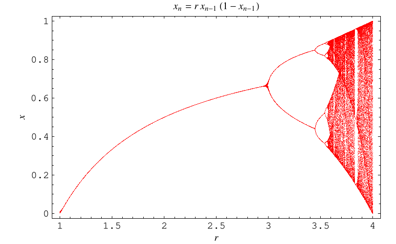

## Very nice video on “logistic mapping”

[video not shown]

## Single population dynamics: Small Rodents

Many, relatively easy long-term studies of small-mammal populations.

Observed that populations fluctuate with higher amplitude and different periods / randomness across latitudinal gradients.

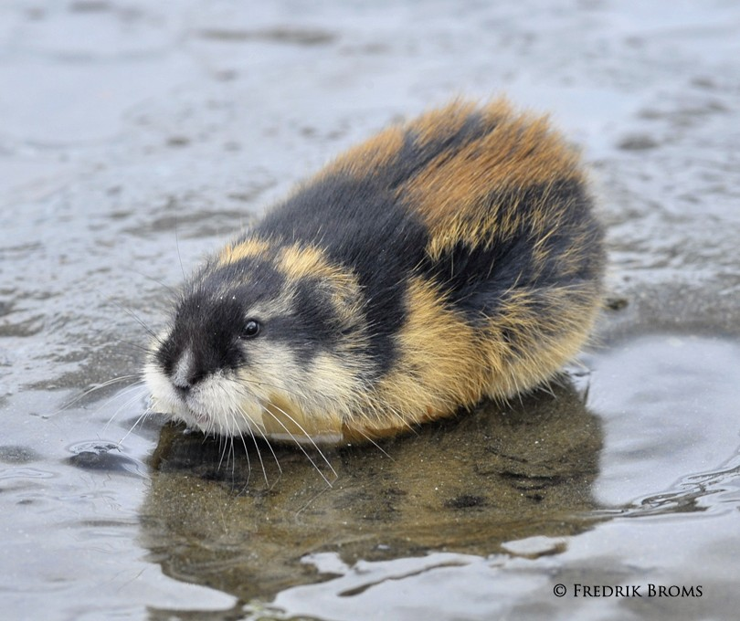

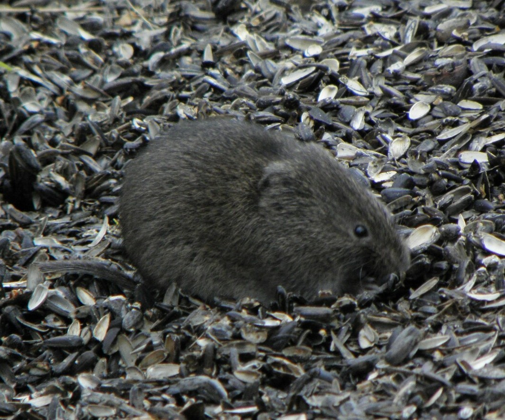

Norway lemming *(Lemmus lemmus)* Tundra vole *(Microtus oeconomus)*

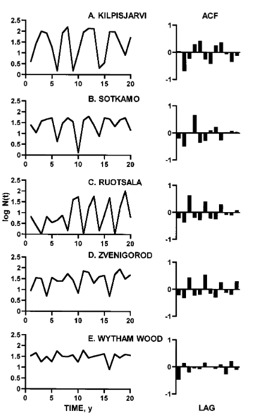

Turchin and Hanski (1997)

## Delayed Density Dependence

\[\log(N_t) = a_0 + a_1 \log(N_{t-1}) + a_2 \log(N_{t-2})\]

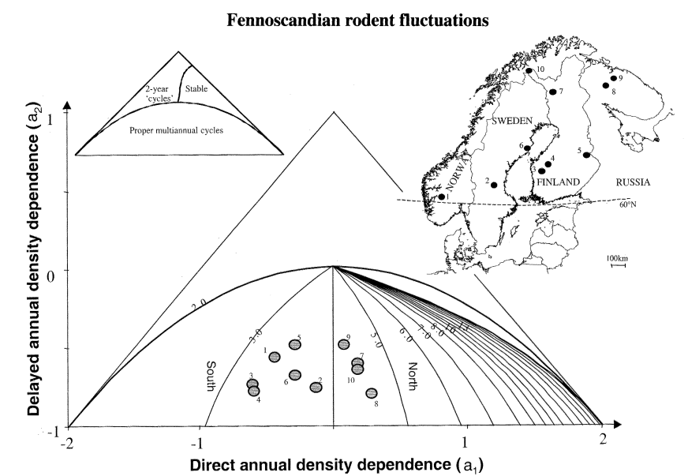

## Lots of data and lots of debate

Are we observing deterministic **chaos** or are we observing *"**stochasticity**?

What *IS* chaos in a stochastic world?

But … methodologically … it is ALL done by fitting SIMPLE LINEAR MODELS.

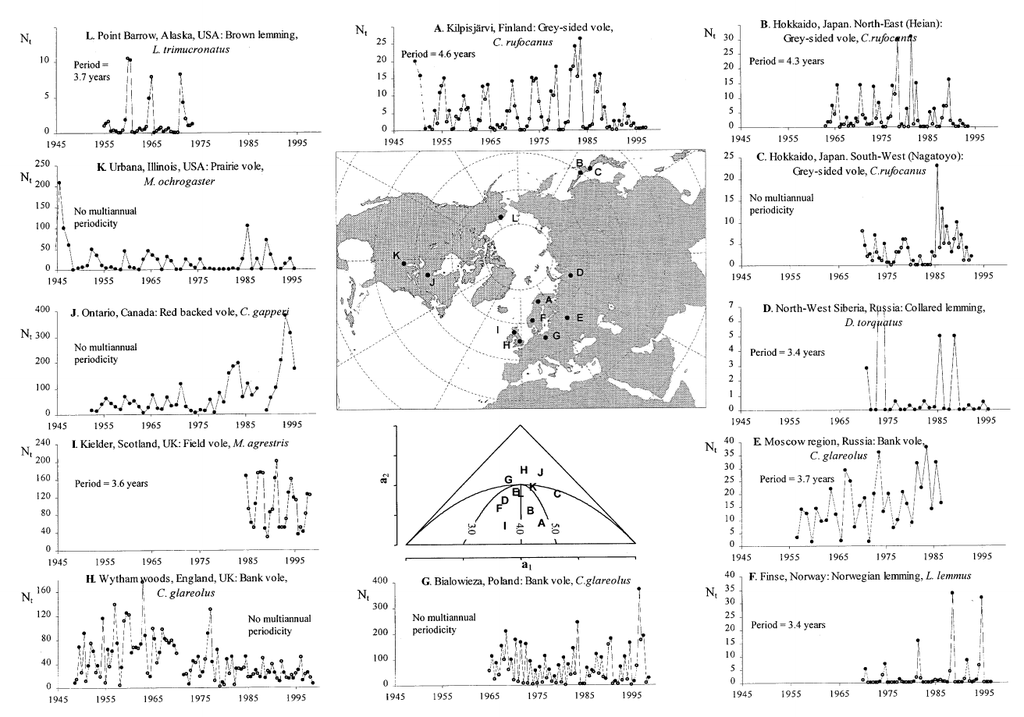

Stenseth (1999) *Oikos*

## Next week (and beyond) ….

We blow up: \[\huge N_t\]

**into:**

- sex / age classes
- multiple sub-populations
- multiple species (competitors / predator-prey)
- infected, susceptible, recovered

**relying on:**

- difference and differential equations
- probability and stochasticity
- visualization and simulation
- statistics (esp. linear modeling)
- *natural history and biological intuition!*